# 利用nCov2019包分析疫情数据

Hope

2020/2/19

本教程聚焦于如何使用南方医科大学余光创老师写的nCov2019包来对疫情数据进行获取、分析与可视化。更详细的资料可参考https://github.com/GuangchuangYu/nCov2019。

## 包的安装

目前包没有上CRAN，只能够在GitHub上直接下载使用。安装方式如下：

```r
remotes::install_github("GuangchuangYu/nCov2019")
```

## 包的加载

```r
library(nCov2019)
```

## 当日数据获取（get_nCov2019）

数据获取仅仅需要一行代码：

```r
x <- get_nCov2019()
```

现在，数据已经存储在x变量中。我们不妨看一下x是什么数据结构：

```r
class(x)
```

```
## [1] "nCov2019"
```

```r
names(x)
```

```
##  [1] "lastUpdateTime"       "chinaTotal"           "chinaAdd"
##  [4] "isShowAdd"            "showAddSwitch"        "chinaDayList"
##  [7] "chinaDayAddList"      "dailyNewAddHistory"   "dailyDeadRateHistory"
## [10] "dailyHealRateHistory" "areaTree"             "articleList"
## [13] "lang"
```

x是一个“nCov2019”类（应该是作者自己起的类名称），一共包含13个部分。我们观察一下数据更新的时间：

```r
x$lastUpdateTime
```

```
## [1] "2020-02-19 15:40:22"
```

其实作者精妙设计下，直接对x进行观察即可：

```r
x #或者 time(x)
```

```
## China (total confirmed cases): 74279
## last update: 2020-02-19 15:40:22
```

如果想看数据的来源，可以键入：

```r
open(x)
```

可以发现该数据来源于腾讯新闻的疫情地图。 如果需要获得全国各个省份的数据，可以直接加中括号：

```r
x[]
```

```
##      name confirm suspect dead deadRate showRate heal healRate showHeal
## 1    湖北   61682       0 1921     3.11    FALSE 9128    14.80     TRUE
## 2    广东    1331       0    5     0.38    FALSE  571    42.90     TRUE
## 3    河南    1262       0   19     1.51    FALSE  552    43.74     TRUE
## 4    浙江    1173       0    0     0.00    FALSE  544    46.38     TRUE
## 5    湖南    1008       0    4     0.40    FALSE  542    53.77     TRUE
## 6    安徽     986       0    6     0.61    FALSE  424    43.00     TRUE
## 7    江西     934       0    1     0.11    FALSE  362    38.76     TRUE
## 8    江苏     631       0    0     0.00    FALSE  296    46.91     TRUE
## 9    重庆     555       0    5     0.90    FALSE  254    45.77     TRUE
## 10   山东     544       0    3     0.55    FALSE  225    41.36     TRUE
## 11   四川     514       0    3     0.58    FALSE  177    34.44     TRUE
## 12 黑龙江     470       0   12     2.55    FALSE  108    22.98     TRUE
## 13   北京     393       0    4     1.02    FALSE  145    36.90     TRUE
## 14   上海     333       0    2     0.60    FALSE  186    55.86     TRUE
```

[output cut: 20 more lines]

如果需要看其中一个省份，可以在中括号中进行标注（比如我们要看湖北省的情况）：

```r
x['湖北']
```

```
##      name confirm suspect dead deadRate showRate heal healRate showHeal
## 1    武汉   44412       0 1497     3.37    FALSE 4895    11.02    FALSE
## 2    孝感    3344       0   82     2.45    FALSE  572    17.11    FALSE
## 3    黄冈    2844       0   85     2.99    FALSE 1059    37.24    FALSE
## 4    荆州    1541       0   38     2.47    FALSE  409    26.54    FALSE
## 5    鄂州    1343       0   37     2.76    FALSE  301    22.41    FALSE
## 6    随州    1280       0   26     2.03    FALSE  254    19.84    FALSE
## 7    襄阳    1165       0   22     1.89    FALSE  230    19.74    FALSE
## 8    黄石     983       0   25     2.54    FALSE  262    26.65    FALSE
## 9    宜昌     907       0   25     2.76    FALSE  208    22.93    FALSE
## 10   荆门     901       0   33     3.66    FALSE  181    20.09    FALSE
## 11   咸宁     832       0   10     1.20    FALSE  225    27.04    FALSE
## 12   十堰     638       0    2     0.31    FALSE  164    25.71    FALSE
## 13   仙桃     562       0   19     3.38    FALSE  149    26.51    FALSE
## 14   天门     486       0   11     2.26    FALSE   73    15.02    FALSE
## 15 恩施州     249       0    3     1.20    FALSE   96    38.55    FALSE
## 16   潜江     185       0    6     3.24    FALSE   40    21.62    FALSE
## 17 神农架      10       0    0     0.00    FALSE   10   100.00    FALSE
```

## 历史数据获取（load_nCov2019）

上面的方法一般是获得最新的数据，如果想要获得历史数据，需要使用`load_nCov2019`函数。使用方法极其简便：

```r
y <- load_nCov2019()
y  #显示历史数据最终更新时间
```

```
## nCov2019 historical data
## last update: 2020-02-13
```

这个数据来源于【新一线城市研究所×8点健闻】，详见[各省市的疫情历史数据来了！](https://mp.weixin.qq.com/s/lrQWGKj-mReWrxfi_4Sw9A)。用法与之前类似：

```r
y[] -> all_province
head(all_province)
```

```
##   province     city       time cum_confirm cum_heal cum_dead 累计重症病例
## 1     上海     上海 2020-02-13         318       62        1
## 2     云南     云南 2020-02-13         162       27        0
## 3     云南     昆明 2020-02-13          48        8        0
## 4     云南     昭通 2020-02-13          19        2        0
## 5     云南 西双版纳 2020-02-13          15        2        0
## 6     云南     曲靖 2020-02-13          13        1        0
##   累计危重病例 confirm dead heal 新增重症病例数量 新增危重病例数量 武汉接触史
## 1                        NA
## 2                        NA
## 3                        NA
## 4                        NA
## 5                        NA
## 6                        NA
##   来源链接             数据来源 公告中是否有病例 其他 X
## 1          上海市卫生健康委员会
## 2          云南省卫生健康委员会
## 3          云南省卫生健康委员会
## 4          云南省卫生健康委员会
## 5          云南省卫生健康委员会
## 6          云南省卫生健康委员会
```

```r
y['湖北'] -> hubei
head(hubei)
```

```
##     province city       time cum_confirm cum_heal cum_dead 累计重症病例
## 251     湖北 武汉 2020-02-13       35991     2023     1016
## 252     湖北 孝感 2020-02-13        3009      255       57
## 253     湖北 黄冈 2020-02-13        2791      528       59
## 254     湖北 荆州 2020-02-13        1447      163       27
## 255     湖北 随州 2020-02-13        1206       72       16
## 256     湖北 襄阳 2020-02-13        1111       73       16
##     累计危重病例 confirm dead heal 新增重症病例数量 新增危重病例数量 武汉接触史
## 251                        NA
## 252                        NA
## 253                        NA
## 254                        NA
## 255                        NA
## 256                        NA
##     来源链接             数据来源 公告中是否有病例 其他 X
## 251          湖北省卫生健康委员会
## 252          湖北省卫生健康委员会
## 253          湖北省卫生健康委员会
## 254          湖北省卫生健康委员会
## 255          湖北省卫生健康委员会
## 256          湖北省卫生健康委员会
```

## 地图可视化

在进行可视化之前，首先要加载地图数据，这也由老师直接提供了，获取方法如下：

```r
remotes::install_github("GuangchuangYu/chinamap")
```

安装后，我们来加载数据：

```r
require(chinamap)
cn = get_map_china()
```

现在，中国地图的信息就在cn变量里面。 目前来说，地图可视化只支持到每天，也就是只能对单一日的疫情数据进行可视化。比如要对今天的数据进行可视化：

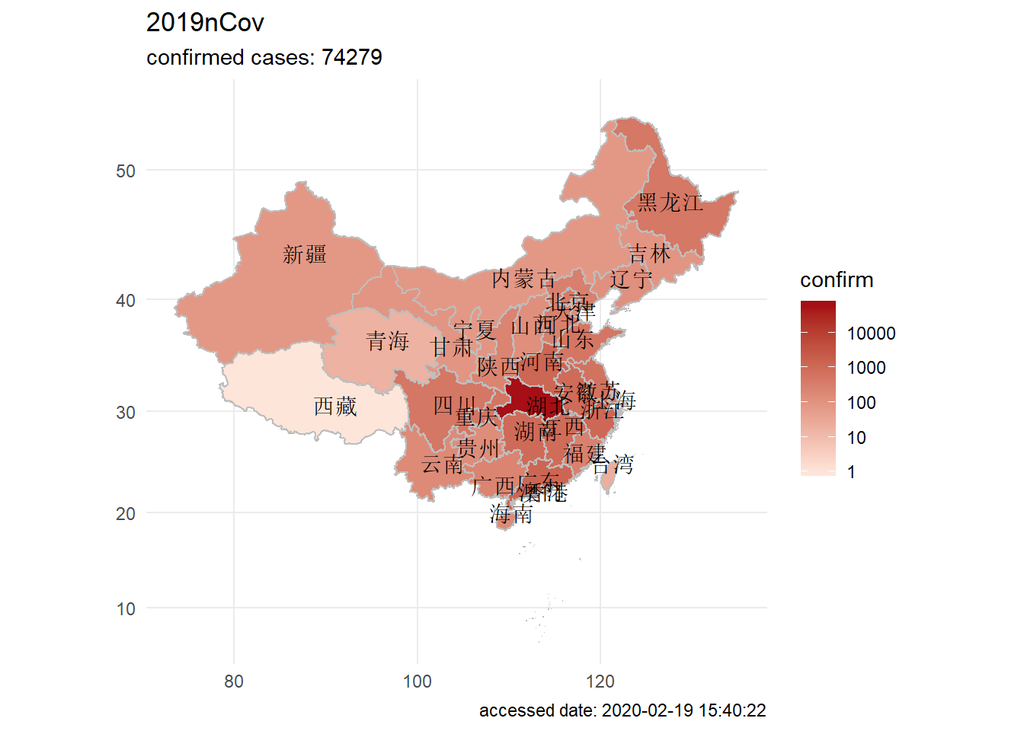

```r
plot(x, region='china', chinamap=cn)
```

其中，palette参数可以改变颜色，continuous_scale可以设置变量是离散还是连续的。例子如下：

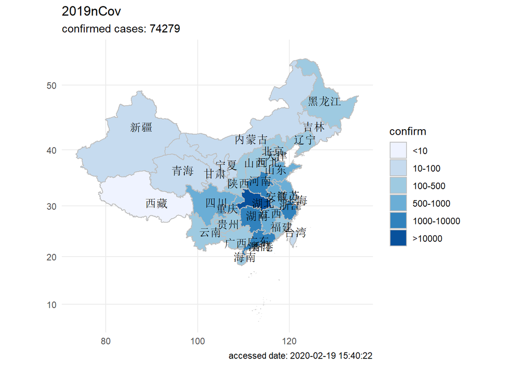

```r
plot(x, region='china', chinamap=cn,
    continuous_scale=FALSE,
    palette='Blues')
```

如果想要画历史数据，则需要指定日期（比如我们想看2020年2月1号的数据）：

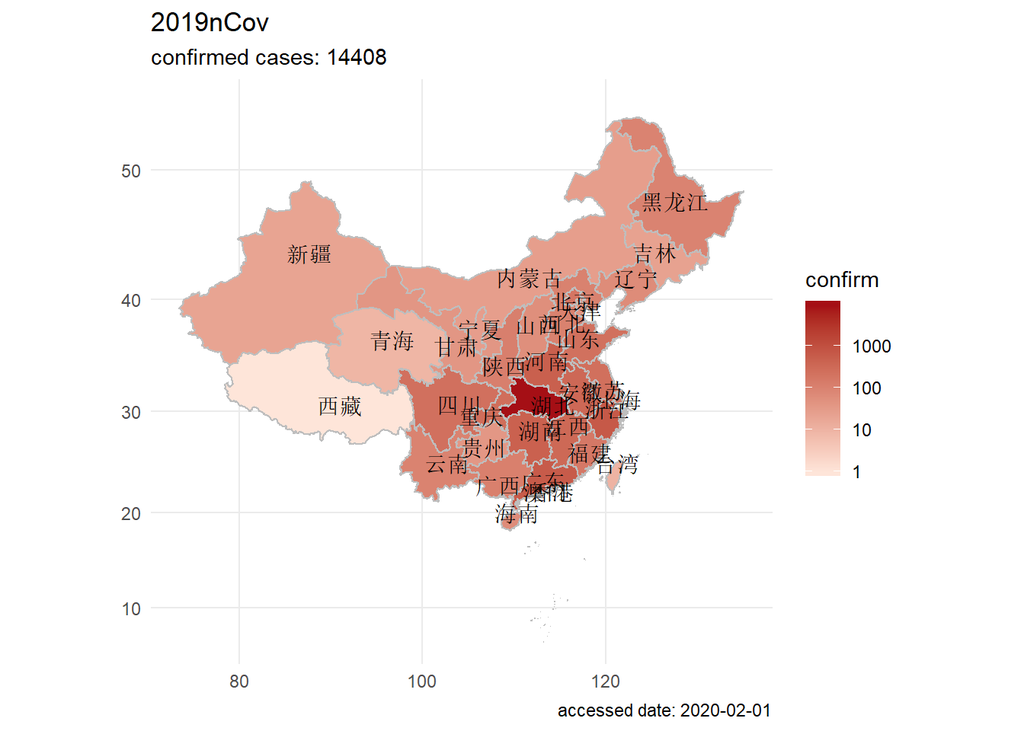

```r
plot(y, region='china',
     chinamap=cn, date='2020-02-01')
```

事实上，只要有底图数据，可视化还能够细化到市级。具体教程可在[一次搞定所有的疫情地图](https://mp.weixin.qq.com/s/iWyOvOoLDl2q9VCUEDY52A) 找到。